# Reproducible Research: Peer Assessment 1

## Imputing missing values

OK. No one is perfect. Even a pedometer. Or maybe sometimes you just take it off, like when you do something else that’s rhythmical and is not walking ;)

Let’s see how much that happened:

```r
colSums(is.na(activity))
```

```
##    steps     date interval  cor_int
##     2304        0        0        0
```

2304!!! That’s a lot of ‘NA’ activity for one person! Maybe it’s Batman and he does not want us to know that so he takes of the pedoemeter when chasing criminals. OK. Now we will replace the NA values. I’m calling BS on that, so I will call the resulting table appropriatly.

I will replace the missing values with an average for that interval throughout the two months.

First, I will merge ‘activity’ data frame with steps_by_cor_int such that I create a variable in each row with an average for that interval.

```r
BS_activity<-merge(activity, steps_by_cor_int, by='cor_int', sort=F)
```

Now, I will run this loop that will look for missing values (steps, in column two) and replace them with average values for that interval (ave_steps, in column five).

```r
for (i in seq_along(BS_activity$steps)){
        if (is.na(BS_activity[i,2])){
                BS_activity[i,2]=BS_activity[i,5]
        }
        else{
                next
        }
}
```

Once again, let’s count the total steps.

```r
bs_activity_by_date<-group_by(BS_activity, date)
bs_daily_steps<-summarize(bs_activity_by_date, steps=sum(steps))
bs_daily_steps
```

```
## Source: local data frame [61 x 2]
##
##          date steps
## 1  2012-10-01 10762
## 2  2012-10-02   126
## 3  2012-10-03 11352
## 4  2012-10-04 12116
## 5  2012-10-05 13294
## 6  2012-10-06 15420
## 7  2012-10-07 11015
## 8  2012-10-08 10762
## 9  2012-10-09 12811
## 10 2012-10-10  9900
## ..        ...   ...
```

OK. So now lets look at the histograms.

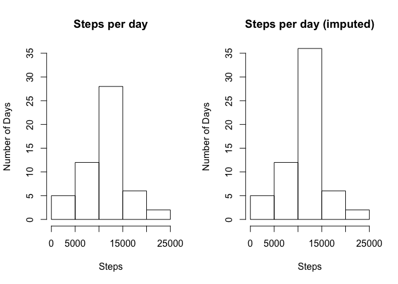

```r
par(mfrow=c(1,2))
hist(daily_steps$steps, main='Steps per day', ylab='Number of Days', xlab='Steps', ylim=c(0,35))
hist(bs_daily_steps$steps, main='Steps per day (imputed)', ylab='Number of Days', xlab='Steps', ylim=c(0,35))
```

They do look a bit different, don’t they?

OK. Let’s see if the mean and median are different.

```r
summary(daily_steps$steps)
```

```
##    Min. 1st Qu.  Median    Mean 3rd Qu.    Max.    NA's
##      41    8841   10760   10770   13290   21190       8
```

```r
summary(bs_daily_steps$steps)
```

```
##    Min. 1st Qu.  Median    Mean 3rd Qu.    Max.
##      41    9819   10760   10770   12810   21190
```

That looks pretty amazing. Notice the difference in the spread of the data (1st and 3rd quantile), but median and mean are the same. Nice.

## Are there differences in activity patterns between weekdays and weekends?

I am running out of time here, so real quick:

Make a weekday variable

```r
BS_activity<-mutate(BS_activity, day=weekdays(date))
```

Create a weekend/weekday vector and cbind it.

```r
day_end<-vector()
for (i in seq_along(BS_activity$date)){
        if (BS_activity[i,6]=='Saturday'){
                day_end[i]<-'Weekend'
        }
        else if ((BS_activity[i,6]=='Sunday'))
                day_end[i]<-'Weekend'
        else{
                day_end[i]<-'Weekday'
        }
}
BS_activity<-cbind(BS_activity, day_end)
head(BS_activity)
```

```
##   cor_int steps       date interval ave_steps      day day_end
## 1       0     2 2012-10-01        0         2   Monday Weekday
## 2       0     0 2012-11-23        0         2   Friday Weekday
## 3       0     0 2012-10-28        0         2   Sunday Weekend
## 4       0     0 2012-11-06        0         2  Tuesday Weekday
## 5       0     0 2012-11-24        0         2 Saturday Weekend
## 6       0     0 2012-11-15        0         2 Thursday Weekday
```

Split the data and calculate the means for each interval on weekends and weekdays separately.

```r
by_day<-group_by(BS_activity, day_end, cor_int)
mean_by_day_and_interval<-summarize(by_day, ave_steps=round(mean(steps, na.rm=T)))
```

Now make the graph! He sleeps in on weekends!

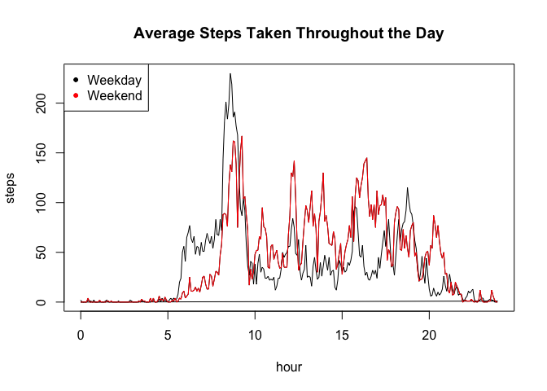

```r
with(mean_by_day_and_interval, plot(cor_int/60, ave_steps, type='l', xlab='hour', ylab='steps', main='Average Steps Taken Throughout the Day'))
with(subset(mean_by_day_and_interval, day_end=='Weekend'), lines(cor_int/60, ave_steps, col='red'))
legend('topleft', col=c('black', 'red'), pch=20, legend=c('Weekday', 'Weekend'))
```